# Redes neuronales convolucionales

## Visión Artificial

Una imagen una computadora lo ve como una matriz de números. Dentro de visión artificial se tienen dos principales tareas:

- Clasificación: Tiene como salida una etiqueta para cada clase. Puede producir la probabilidad de pertenecer a una clase determinada. Primero se tienen que detectar características de alto nivel, así podemos determinar con más facilidad qué tipo de imagen tenemos. Es complicado obtener las características ya que en una imagen obtenemos información bidimensional y mucho del mundo que estamos capturando es tridimensional, por lo que muchas características se pierden. Una red neuronal puede entrenarse con diferentes imágenes de lo que queremos detectar.
- Regresión: La variable de salida es continua.

### Imágenes en una red neuronal

Podemos ingresar la imagen en una red completamente conectada, por lo que tendríamos que transformar nuestra imagen bidimensional a un vector de una dimensión, perdiendo información epacial y al aumentar el número de neuronas tenemos más parámetros que optimizar.

Otra forma de hacer esto es utilizando parches o ventanas, donde se van tomando segmentos de la imagen, realizando una convolución, donde el resultado de la suma ponderada es la salida de una neurona.

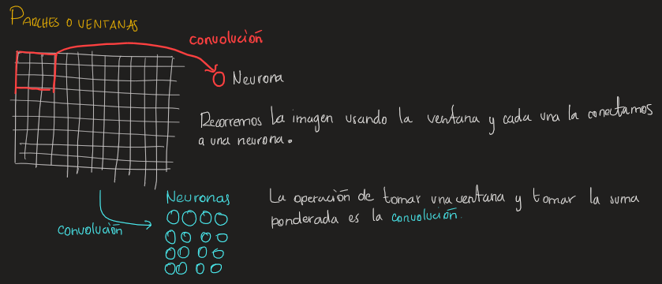

La **convolución** toma como entrada dos funciones y da como salida otra función. Para imágenes, toma como entrada dos imágenes y da como salida una imagen. Tomando la idea de las ventanas, podemos definir una ventana que sirva para encontrar algún patrón dentro de la imagen, luego realizar la convolución y observar en la salida dónde se encuentran estos patrones.

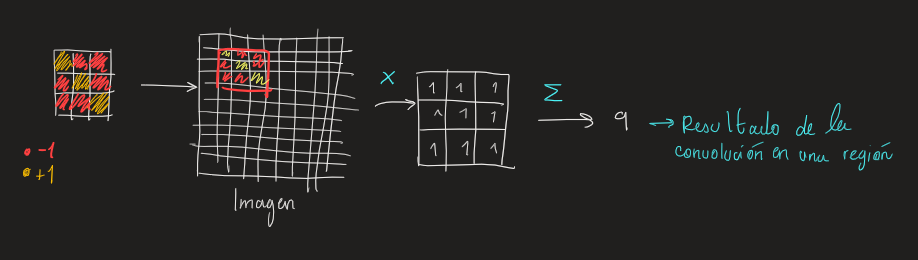

Esta operación de convolución es utilizada para aplicar filtros espaciales en imágenes, así podemos obtener bordes en diferentes orientaciones, o dependiendo del filtro podemos extraer características de las imágenes. Cambiando los pesos de las ventanas, podemos intensificar ciertas características. Al realiar esta operación, estamos conservando información espacial.

## Redes neuronales convolucionales

Se llaman así porque de forma fundamental realizan la misma función de convolución. Para una imagen, una red neuronal de este tipo realiza tres principales operaciones:

1. **Convolución:** Aplica filtros a una imagen.
2. **Función no lineal:** Como la función ReLU.
3. **Pooling**: Es una capa que reduce las dimensiones de nuestras características.

Matemáticamente, si tomamos una ventana de 4x4 la operación que se realiza es la siguiente para cada neurona:

$$ \sum_{i=1}^{4} \sum_{j=1}^{4} w_{i j} x_{i+p_{v} j+q}+b $$

De esta manera se forma una imagen para cada filtro, entonces tenemos un arreglo tridimensional donde la profundidad es el resultado de aplicar diferentes filtros.

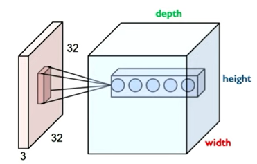

Así una capa de la red tiene dimensiones $h \times w \times d$ con $d$ filtros. Luego se aplica una función no lineal, como la función ReLU, la cual deja pasar sólo los valores que sean no negativos.

Luego de aplicar la función no lineal se realiza el *pooling* que permite reducir las dimensiones de nuestro resultado, una forma de hacer es aplicar *max pooling*, donde se toma el valor máximo de una ventana.

Poniendo diferentes de estas capas en serie, obtenemos la red neuronal convolucional, de forma que llegamos a un momento donde tenemos menor cantidad de salidas y entonces podemos conectar estas salidas a una red complentamente conectada y realizar la tarea de clasificación.

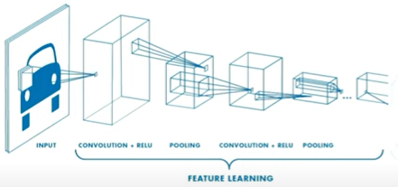

### Detección de objetos

Una forma de detectar objetos podría ser tomar muetras aleatorias de la imagen e identificar si hay algún objeto en esa muestra; esto puede ser una forma sencilla de resolver el problema pero tiene muchas desventajas, como que tenemos que tomar una gran cantidad de muestras de la imagen.

Otra forma de hacerlo es mediante R-CNN, el cual es un algoritmo que identifica señales en la imagen que puedan representar algún objeto importante, y estos segmentos de imagen se pasan a una red neuronal convolucional, pero tiene la desventaja de ser muy lento.

Se han propuesto diferentes soluciones y una de estas es Faster R-CNN, donde se agrega una capa donde hay una red que propone regiones donde pueden haber objetos para clasificar que sean importantes. Esta capa es parte de la red neuronal y recibe la imagen completa.

### Segmentación

Se trata de clasificar cada pixel de una imagen. Para ello se suele usar una FCN (Fully Convolutional Network). Lo primero que se hace es la operación de extracción de características y clasificación, después se usan convoluciones transpuestas, donde tomamos nuestra imagen reducida y volvemos a obtener una imagen de las mismas dimensiones que la original, pero con los pixeles clasificados.

### Vehículos autónomos

En este caso se tienen diferentes cámaras que extraen características del ambiente, también se tiene información de GPS y se pasan por una red neuronal convolucional. Cada una de estas pasa por una capa completamente conectada y posteriormente se hace la predicción de qué camino puede tomar.